# Reproducible Research: Peer Assessment 1

Samuel Tandoh

2/8/2021

## Loading and preprocessing the data

### Show any code that is needed to

1. *Load the data (i.e. read.csv())*
2. *Process/transform the data (if necessary) into a format suitable for your analysis*

```r
unzip(zipfile="activity.zip")
activity <- read.csv("activity.csv")
```

- Loading libaries

```r
library(ggplot2)
library(dplyr)
Sys.setlocale("LC_TIME", "English")
```

```
## [1] "English_United States.1252"
```

- Information about data variables

```r
str(activity)
```

```
## 'data.frame':    17568 obs. of  3 variables:
##  $ steps   : int  NA NA NA NA NA NA NA NA NA NA ...
##  $ date    : chr  "2012-10-01" "2012-10-01" "2012-10-01" "2012-10-01" ...
##  $ interval: int  0 5 10 15 20 25 30 35 40 45 ...
```

From the output, there are 17568 observations with 3 variables included in this dataset are:

1. *steps* : Number of steps taking in a 5-minute interval (missing values are coded as NA)
2. *date* : The date on which the measurement was taken in YYYY-MM-DD format
3. *interval*: Identifier for the 5-minute interval in which measurement was taken

## What is mean total number of steps taken per day?

For this part of the assignment, you can ignore the missing values in the dataset.

1. *Calculate the total number of steps taken per day*
2. *Make a histogram of the total number of steps taken each day*
3. *Calculate and report the mean and median total number of steps taken per day*

**1. Number of steps per day**

```r
tot.steps_perday <- aggregate(activity$steps, list(activity$date), FUN=sum)
colnames(tot.steps_perday) <- c("Date", "Steps")
tot.steps_perday
```

```
##          Date Steps
## 1  2012-10-01    NA
## 2  2012-10-02   126
## 3  2012-10-03 11352
## 4  2012-10-04 12116
## 5  2012-10-05 13294
## 6  2012-10-06 15420
## 7  2012-10-07 11015
## 8  2012-10-08    NA
## 9  2012-10-09 12811
## 10 2012-10-10  9900
## 11 2012-10-11 10304
## 12 2012-10-12 17382
## 13 2012-10-13 12426
## 14 2012-10-14 15098
```

[output cut: 47 more lines]

**2. Histogram of the total number of steps taken each day**

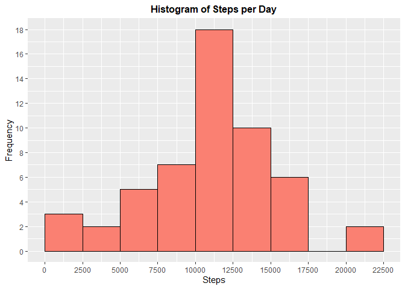

```r
g <- ggplot(tot.steps_perday, aes(Steps))
g+geom_histogram(boundary=0, binwidth=2500, col="black", fill="salmon")+
    ggtitle("Histogram of Steps per Day")+
    xlab("Steps")+
    ylab("Frequency")+
    theme(plot.title = element_text(hjust = 0.5, face="bold", size=12))+
    scale_x_continuous(breaks=seq(0,25000,2500))+scale_y_continuous(breaks=seq(0,20,2))
```

**3. Mean and median of total number of steps taken per day**

```r
round(mean(tot.steps_perday$Steps, na.rm = TRUE))
```

```
## [1] 10766
```

```r
median(tot.steps_perday$Steps, na.rm = TRUE)
```

```
## [1] 10765
```

The mean and median of the total steps taken per day are *10766* and *10765* respectively

## **What is the average daily activity pattern?**

**1. Time series plot of the 5 minute interval (x) and averaged number of steps taken averaged across all days (y)**

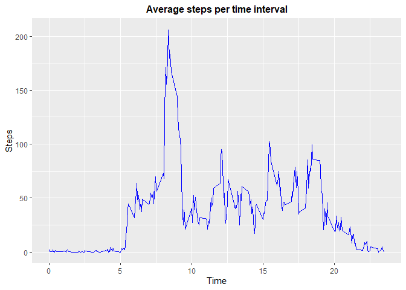

```r
steps_per.time <- aggregate(steps~interval,data=activity,FUN=mean,na.action=na.omit)

steps_per.time$time <- steps_per.time$interval/100

h <- ggplot(steps_per.time, aes(time, steps))
h+geom_line(col="blue")+
    ggtitle("Average steps per time interval")+
    xlab("Time")+
    ylab("Steps")+theme(plot.title = element_text(hjust = 0.5, face="bold", size=12))
```

## **Imputing missing values**

**1. calculating the total number of missing values in the dataset**

```r
activity2 <- tibble::as_tibble(activity)

activity2 %>%
  filter(is.na(steps)) %>%
  summarize(missing_values = n())
```

```
## # A tibble: 1 x 1
##   missing_values
##            <int>
## 1           2304
```

As we can see, the original data set has 2304 rows with missing data.

**2. Replace missing values**

We use the mean for that 5-minute interval to replace all missing values.We create a new column without missing values called *full_steps*

```r
activity$full_steps <- ifelse(is.na(activity$steps), round(steps_per.time$steps[match(activity$interval, steps_per.time$interval)],0), activity$steps)
```

**3. Creating new dataset that is equal to the original dataset but with the missing data filled in**

```r
activity_comp <- data.frame(steps=activity$full_steps, interval=activity$interval, date=activity$date)
# see first 10 values of the new dataset
head(activity_comp, n=10)
```

```
##    steps interval       date
## 1      2        0 2012-10-01
## 2      0        5 2012-10-01
## 3      0       10 2012-10-01
## 4      0       15 2012-10-01
## 5      0       20 2012-10-01
## 6      2       25 2012-10-01
## 7      1       30 2012-10-01
## 8      1       35 2012-10-01
## 9      0       40 2012-10-01
## 10     1       45 2012-10-01
```

**4a. Histogram of the total number of steps taken each day with missing data filled in**

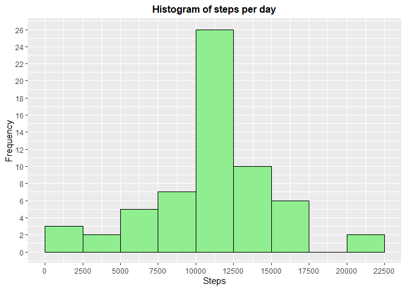

```r
steps_perday_comp <- aggregate(activity_comp$steps, list(activity_comp$date), FUN=sum)
colnames(steps_perday_comp) <- c("Date", "Steps")

# draw the histogram
g <- ggplot(steps_perday_comp, aes(Steps))
g+geom_histogram(boundary=0, binwidth=2500, col="black", fill="lightgreen")+
  ggtitle("Histogram of steps per day")+
  xlab("Steps")+ylab("Frequency")+
  theme(plot.title = element_text(hjust = 0.5, face="bold", size=12))+
  scale_x_continuous(breaks=seq(0,25000,2500))+
  scale_y_continuous(breaks=seq(0,26,2))
```

**4b. Calculate and report the mean and median total number of steps taken per day.** **Do these values differ from the estimates from the first part of the assignment?** **What is the impact of imputing missing data on the estimates of the total daily number of steps?**

```r
round(mean(steps_perday_comp$Steps))
```

```
## [1] 10766
```

```r
median(steps_perday_comp$Steps)
```

```
## [1] 10762
```

## **Are there differences in activity patterns between weekdays and weekends?**

**1. Creating a new factor variable in the dataset with two levels - “weekday” and “weekend” indicating whether a given date is a weekday or weekend day.**

```r
activity_comp$RealDate <- as.Date(activity_comp$date, format = "%Y-%m-%d")
# create a variable with weekdays name
activity_comp$weekday <- weekdays(activity_comp$RealDate)
# create a new variable indicating weekday or weekend
activity_comp$day_type <- ifelse(activity_comp$weekday=='Saturday' | activity_comp$weekday=='Sunday', 'weekend','weekday')
# see first 10 values
head(activity_comp, n=10)
```

```
##    steps interval       date   RealDate weekday day_type
## 1      2        0 2012-10-01 2012-10-01  Monday  weekday
## 2      0        5 2012-10-01 2012-10-01  Monday  weekday
## 3      0       10 2012-10-01 2012-10-01  Monday  weekday
## 4      0       15 2012-10-01 2012-10-01  Monday  weekday
## 5      0       20 2012-10-01 2012-10-01  Monday  weekday
## 6      2       25 2012-10-01 2012-10-01  Monday  weekday
## 7      1       30 2012-10-01 2012-10-01  Monday  weekday
## 8      1       35 2012-10-01 2012-10-01  Monday  weekday
## 9      0       40 2012-10-01 2012-10-01  Monday  weekday
## 10     1       45 2012-10-01 2012-10-01  Monday  weekday
```

```r
str(activity_comp)
```

```
## 'data.frame':    17568 obs. of  6 variables:
##  $ steps   : num  2 0 0 0 0 2 1 1 0 1 ...
##  $ interval: int  0 5 10 15 20 25 30 35 40 45 ...
##  $ date    : chr  "2012-10-01" "2012-10-01" "2012-10-01" "2012-10-01" ...
##  $ RealDate: Date, format: "2012-10-01" "2012-10-01" ...
##  $ weekday : chr  "Monday" "Monday" "Monday" "Monday" ...
##  $ day_type: chr  "weekday" "weekday" "weekday" "weekday" ...
```

**2. A panel plot containing a time series plot (i.e. type = “l”) of the 5-minute interval (x-axis) and the average number of steps taken, averaged across all weekday days or weekend days (y-axis).**

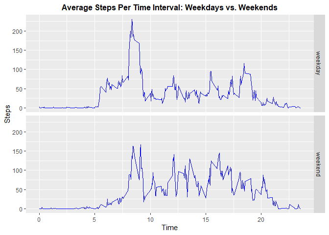

```r
steps_per_timedf <- aggregate(steps~interval+day_type,data=activity_comp,FUN=mean,na.action=na.omit)

steps_per_timedf$time <- steps_per.time$interval/100
# draw the line plot
z <- ggplot(steps_per_timedf, aes(time, steps))
z+geom_line(col="blue")+
  ggtitle("Average Steps Per Time Interval: Weekdays vs. Weekends")+
  xlab("Time")+
  ylab("Steps")+
  theme(plot.title = element_text(hjust = 0.5, face="bold", size=12))+
  facet_grid(day_type ~ .)
```